[figure not shown]

# matplotlib初级教程（Intro to pyplot）

主要任务：初步介绍matplotlib模块下的子模块[pyplot](https://matplotlib.org/api/_as_gen/matplotlib.pyplot.html)的使用，pyplot是一个2-D绘图库，主要用于绘制一元函数图像（若绘制二元函数应使用3-D绘图库）。pyplot提供了一套类似于MATLAB的命令风格的函数式绘图工具（同时也提供了面向对象的绘图工具），和Matlab一样，pyplot中有当前图像（figure）和当前轴域（axes）的概念，所有的作图命令都是对当前的对象作用。可以通过gca()获得当前的axes，通过gcf()获得当前的figure，每个绘图函数都会对图像做出特定的改变，譬如：创建一个图像（figure）、在一个图像中创建一个绘图区域（plotting area）、在一个绘图区域中绘制线条（line）、使用标签装饰制图（plot）等。  
应着重理解figure、subplot、axes三个对象：  
figure是最大的单位或者说范畴，其中可以包含多个子图（subplot/axes），可以认为subplot和axes是同一概念，都是指子图对象，在翻译时称axes为“轴域”，即整个坐标系区域。它们的区别似乎主要在于：subplot用于创建规则的行列子图矩阵，而axes可以在任意指定位置创建子图，更具灵活性，subplot创建的子图是不可重叠的，而axes可以，即axes可以用来创建内嵌子图。  
其他概念（concept）：  
在最简单的绘图工作中，我们使用plot()创建一个绘图区域（plotting area），然后我们在这个区域中绘制线条、散点、柱状图等，实际上这个绘图区域就相当于是一个一行一列编号为1的子图对象（subplot(111)）。当你要指代一个只具有一个直角坐标系的子图对象的时候，为了区别于之前的图像（figure）概念，我们使用plot（制图）来标识，在接下来的文档说明中，我不会再使用中文，因为实在难以区分。因此subplot、plot、axes其实都是一回事，都是一个可以用于绘图的最小plotting area。

## 学习和实验

```python
import matplotlib.pyplot as plt
import numpy as np
from mpl_toolkits.mplot3d import Axes3D
from matplotlib import colors as mcolors
plt.rcParams['font.sans-serif']=['SimHei']
plt.rcParams['axes.unicode_minus']=False
import scipy.stats
from PIL import Image
```

### 最简单的绘图工作

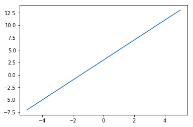

```python
# 绘制函数图像：y=2x+3
# x区间：[-5,5]
x=np.linspace(-5,5,2) # 由于绘制的是直线，而两点确定一条直线，所以只要两个端点即可
# The coordinates of the points or line nodes are given by x, y.
plt.plot(x,2*x+3) # 此处plot()接受两个参数，分别表示x轴坐标（自变量）和对应的y轴坐标（因变量）
```

说实话，对这张图，我特别不满意，它经过哪些点？两个端点的刻度没有显示出来？刻度怎么调整，乍一看，我还以为是y=0.5x呢！最重要的是仅仅从这张图，我完全没有办法恢复出函数原型，缺少必要的图像说明啊！但是也不用担心，这些问题以后会得到解决。

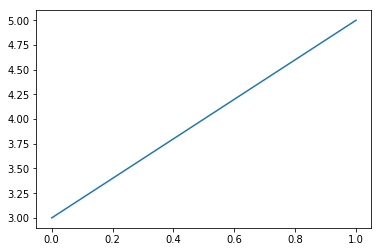

```python
# 两点确定一条直线（y=2x+3）：
plt.plot([3,5]) # 找两个点：当x=0和x=1时（只能找这两个点），y分别为3和5
```

此处的函数调用可能令人疑惑不解，为什么x-axis的取值为0-1而y-axis的取值为3-5？因为当你只提供一个（一维）列表或数组的时候（记作a），plot()命令将视其为y（因变量）的一系列取值，而相应的x（自变量）将为：range(0,len(a))，即plot(a)自动转换为plot(range(0,len(a)),a)

### 基本绘图命令（线形图）

#### plot()可以在同一plotting area绘制（具现化）多个函数关系

函数原型：`matplotlib.pyplot.plot(*args, scalex=True, scaley=True, data=None, **kwargs)`  
调用签名（Call signatures 这什么意思？）：  
`plot([x], y, [fmt], data=None, **kwargs)`或者  
`plot([x1], y1, [fmt1], [x2], y2, [fmt2], ..., **kwargs)`，其中`[]`表示可选参数  
返回值：A list of Line2D objects

注：matplotlib出图的过程和我们画图过程差不多，先生成 X 的一个取值数组，如要画区间[0,1]的图像，则先取[0,1]之内的一组数组(如:x=arange(0,1,0.01)表示 x 以 0.01 为步长取 100 个点)，然后取对应 x 的 y 的值的一组数据，这样以坐标(x,y)画出的图就是一条曲线了，点和点之间以直线相连，因此曲线的光滑程度完全取决于点的细密程度  
Format Strings：  
fmt用于定义几种特定的线条对象（Line2D）的外观（appearance）属性：颜色、标记和线条样式，在不对外观进行任何设置的情况下，线条默认为“无点标记的蓝色实线”；fmt是一个快捷的格式化字符串（定义：fmt = '[color][marker][line]'，color、marker和line都是任意可缺省的，默认选项分别为：'b'、''、'-'，表示“蓝色”、“无标记”、“实线”，如果三者同时缺省，那还不如不设置fmt参数；注意：当fmt只设置颜色属性时，可以使用任何matplotlib.colors规范，例如颜色全名（绿色："green"）或颜色的十六进制字符串代码（绿色："008000"）；特别注意：当提供了marker参数时，其认为我们的本意是绘制散点图，因此此时line=''，除此以外当line缺省时，都是默认line='-'</font>），每个字符表示一种特征，这个字符串可以是特征的任意组合；fmt的功能完全可以通过给定键值对形式的Line2D对象属性作为函数参数来实现，且后者提供了完备的外观设定（譬如线条宽度、标记大小等），fmt仅仅具有某些常见外观设置上的方便性；当fmt和Line2D的关键字属性产生冲突时，后者优先。

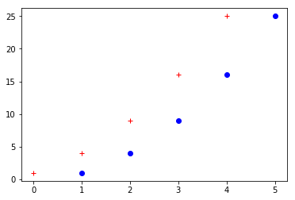

```python
x,y=[1,2,3,4,5],[1,4,9,16,25]
plt.plot(x,y,'bo')
plt.plot(y,'r+') # 在当前plotting area上继续绘制并显示修改（只在交互模式起效）
```

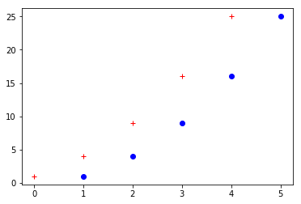

```python
plt.plot(x,y,'bo',y,'r+') # 同时具现化两种函数关系
```

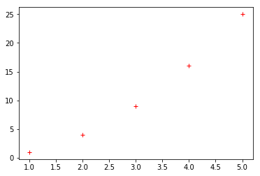

```python
plt.plot(x,y,color='red',marker='+',linestyle='') # 等同于plot(x,y,'r+')，可见fmt格式字符串的方便性
```

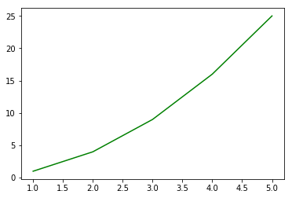

```python
plt.plot(x,y,'green') # fmt格式字符串在用于单独设置颜色属性时，可以指定颜色全名或其十六进制代码
```

Plotting labelled data：  
plot()提供了一种通过标记数据创建plot的方式，所谓标记数据，指的是可以通过`data['label']`标签索引来获取所需数据的方式，显然，字典对象就符合条件。从之前的实验可知：plot()参数接受两个参数，自变量x和因变量y（它们都是一维序列），因此，我们应当能够从标记数据中根据指定的标签获取所需的自变量和因变量数据。字典对象应该是这样的：dict={'xlabel':[...],'ylabel':[...],...}，于是有：x=dict['xlabel']，y=dict['ylabel']，但我们无需通过plot(dict['xlabel'],dict['ylabel'])的方式调用，而是：`plot('xlabel','ylabel',data=dict)`  
**注**：符合条件的标记数据可以是字典对象、pandas.DataFame或numpy的结构化数组（All indexable objects are supported. This could e.g. be a dict, a pandas.DataFame or a structured numpy array.）

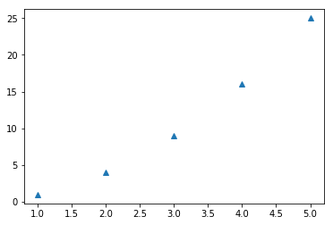

```python
# 从字典对象创建plot
dicts={'x-axis':[1,2,3,4,5],'y-axis':[1,4,9,16,25]}
plt.plot('x-axis','y-axis',data=dicts,marker='^',linestyle='')
```

```
[[(b'daiyang', 165., 58.5, 1) (b'zhouqifei', 170., 57. , 1)
  (b'daixiaodong', 173., 59.5, 1) (b'miaosiyu', 166., 53.5, 1)]
 [(b'liuwenwei', 167., 54.6, 2) (b'liushaoliang', 175., 55.5, 2)
  (b'daizhongliang', 178., 58. , 2) (b'zhangjingjing', 166., 52. , 2)]]
[(b'daiyang', 165., 58.5, 1) (b'zhouqifei', 170., 57. , 1)
 (b'daixiaodong', 173., 59.5, 1) (b'miaosiyu', 166., 53.5, 1)]
```

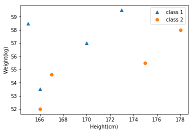

```python
# 从numpy结构化数组创建plot，通过字段名获取的数据应为一维
# 现有一个结构化数组，其中存储了不同班级的学生的身高、体重信息，数组的形状无关紧要，因为“记录”的数据结构中的信息十分完备，我们不需要依靠数组的维度来区分不同的班级
# 要求根据不同的班级，绘制学生的身高-体重分布（绘制散点图一般使用scatter()，没什么区别，就是用起来简洁一点）
a=np.array([[('daiyang',165,58.5,1),('zhouqifei',170,57,1),('daixiaodong',173,59.5,1),('miaosiyu',166,53.5,1)],[('liuwenwei',167,54.6,2),('liushaoliang',175,55.5,2),('daizhongliang',178,58,2),('zhangjingjing',166,52,2)]],dtype=[('name','S20'),('height','f'),('weight','f'),('class','i4')])
print(a)
t=a[a['class']==1] # 布尔索引：和数组掩码相与返回的结果是一个一维数组，其中是符合条件的元素
print(t)
plt.plot('height','weight',data=t,marker='^',linestyle='',label='class 1')
plt.plot('height','weight',data=a[a['class']==2],marker='o',linestyle='',label='class 2')
plt.legend()
plt.xlabel('Height(cm)')
plt.ylabel('Weight(kg)')
```

Plotting multiple sets of data：  
在同一plotting area绘制多次数据集，有多种实现方式：  
**1)** 最直接的方式就是多次调用plot()（仅限于交互模式）  
**2)** 如果已有的数据是一个二维数组，那么可以将某一列指为x，其余列指为y（此前，我们的plot()接受两个参数，一个是x，一个是y，分别表示点在x轴上和y轴上的坐标，x与y都是一维的等长的序列，而此处很显然，y是一个二维的数组了，这是最显著的区别，但是须保证：x（一维）的长度与y（二维）的0轴长度一致），若“其余列”共有n列，那么相当于法1)执行n次plot()：plot(x,y[:,0])、plot(x,y[:,1])、plot(x,y[:,2])、...plot(x,y[:,n-1])，即根据x和y的每一列分别逐一地绘制相应的线条  
**3)** 指定多组 [x],y,[fmt] 的组合，plot函数将会为每一数据集（x和y）分别进行绘制，[]表示可选，前面我们已经举过示例，譬如：plot(x1,y1,'red',x2,y2,'pink')，但应当注意的是，当存在多个组合时，fmt不能随意省略，fmt可以充当不同组合的分隔标识，这种分隔标识将为系统所理解，虽然文档没有提及，但这确是为实践所检验的真理。在此情况下，任何其他关键字参数都适用于所有数据集

```
[[ 0  1  2]
 [ 3  4  5]
 [ 6  7  8]
 [ 9 10 11]]
```

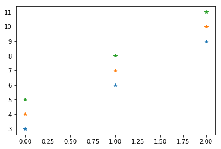

```python
data=np.arange(12).reshape(4,3)
print(data)
plt.plot(data[0],data[1:],marker='*',linestyle='') # 以某一行作为x，其余行作为y，这种方式不推荐，虽然可行，但是由于绘制的行为总是：
# 取x（一维）和y（二维）的每一列作为一配对进行一次绘制，x的长度必须与y的0轴长一致，所以要满足这一点，则data只能为m*(m-1)型二维数组，譬如4*3、7*6等
```

```
[[ 0  1  2]
 [ 3  4  5]
 [ 9 10 11]]
```

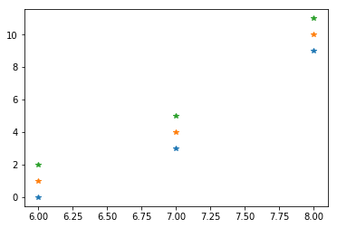

```python
print(data[[0,1,3]])
plt.plot(data[2],data[[0,1,3]],marker='*',linestyle='') # 将第3行作为x，将其余行作为y
```

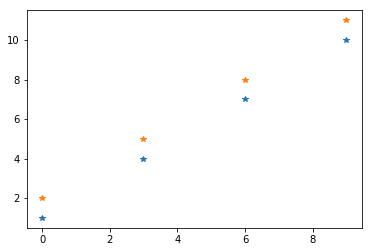

```python
plt.plot(data[:,0],data[:,1:],marker='*',linestyle='') # 将第0列作为x，将其余列作为y
```

```python
# 实际上，对于plt.plot(x,y)来说，x、y都可以是二维数组，但行数需一致，若列数不同，首先对x或y进行扩展，使得两个数组形状完全一致。假设x有m列，y有
# n列，m<n，且n-m=r，则对x进行扩展，将x的第0列到第r-1列（前r列）沿1轴添加到x上，使成为n列数组，x、y形状一致。于是plot()可以绘制n条线，分别取x和y的
# 第1列绘制第一条线，再取x和y的第2列绘制第二条线...
plt.plot(data,data[:,1:],marker='.')
print(data) # 参数x
print(np.hstack((data[:,1:],data[:,0:1]))) # 参数y扩展后，与参数x形状相同
```

```
[[ 0  1  2]
 [ 3  4  5]
 [ 6  7  8]
 [ 9 10 11]]
[[ 1  2  0]
 [ 4  5  3]
 [ 7  8  6]
 [10 11  9]]
```

[figure not shown]

```
[[ 0  1  2  3  4  5  6]
 [ 7  8  9 10 11 12 13]
 [14 15 16 17 18 19 20]
 [21 22 23 24 25 26 27]]
```

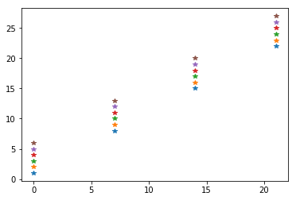

```python
d=np.arange(28).reshape(4,7)
print(d)
plt.plot(d[:,0],d[:,1:],marker='*',linestyle='')
```

```
[[ 0  1  2  3  4]
 [ 5  6  7  8  9]
 [10 11 12 13 14]]
```

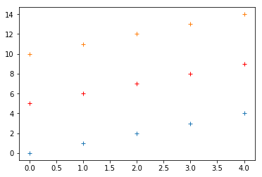

```python
x=range(5)
y=np.arange(15).reshape(3,5)
print(y)
plt.plot(x,y[0],y[1],'r^',x,y[2],linestyle='',marker='+') # marker关键字参数设置适用于全部三条线，且关键字参数优先于fmt设置
```

#### subplot()向当前figure中添加子图（子画板），当多次添加时，全部子图将以子图矩阵的方式呈现

函数原型：`matplotlib.pyplot.subplot(*args, **kwargs)`  
Call signatures:  
`subplot(nrows, ncols, index, **kwargs)`  
`subplot(pos, **kwargs)`  
`subplot(ax)`  
**args**参数：一个3位整数或三个独立的整数（只有当三个整数都小于等于9才能写成一个三位整数），用于描述子图在子图矩阵中的位置。三个整数按顺序为nrows，ncols和index，分别表示行、列、索引。nrows和ncols将构成一个既定的子图矩阵，其中每一个子图都拥有一个唯一的索引编号，其是C风格的索引，根据索引我们可以指定子图矩阵中的任意子图对象。  
**projection**参数：{None, 'aitoff', 'hammer', 'lambert', 'mollweide', 'polar', 'rectilinear', str}, optional  
设置子图的“投影类型”，其中我最熟悉的就是'polar'极坐标系（也可用polar()绘制极坐标系）。默认情况下，projection='rectilinear'  
**polar**参数：True or False，当其为True时，等同于projection='polar'  
**sharex,sharey**参数：Axes, optional  
参数接受一个axes对象（记作a），即一个画板，使当前axes与a共享x-axis或y-axis（The axis will have the same limits, ticks, and scale as the axis of the shared axes.）  
**kwargs**关键字参数设置其他axes属性，当投影非默认时，即采用其他投影则可能还有其他关键字参数，属性[参见](https://matplotlib.org/api/_as_gen/matplotlib.pyplot.subplot.html#matplotlib.pyplot.subplot)  
**label**参数：具体使用？  
subplot()是对Figure.add_subplot的包装，但是有一些行为上的细微的差别：见文档 Note 部分  
靠，没整明白啊  
须知，plot()是用笔绘制图形，而figure()或subplot()是在准备画板等初步工作，此前（我们的实验）虽然没有写过figure()或者subplot()，但是它们都是被默认执行了的，又当我们添加语句figure()或subplot()，其实际上是为：figure(1)、subplot(111)  
当我准备好第一块子画板，并进行某些线条绘制后，来到第二块子画板，突然发现，第一块有所欠缺，想做修改，但是系统当前axes对象已经切换到了第二块子画板，怎么回去到上一块子画板呢？Matplot命令我还真不知道怎么“切换”，我是利用面向对象的方法，每次执行subplot()时将返回值保存下来即可获取当时创建的axes对象，也就是那块子画板，然后直接用面向对象绘制线条等，如果仍想使用命令风格，则可利用`sca()`将某一子画板设置为“系统当前axes”（set current axes）  
如果创建了多个figure对象：  
`plt.figure(1)`  
`plt.figure(2)`  
`...` 对figure的切换，仍然调用`plt.figure(编号)`即可切换至指定编号的figure

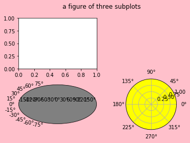

```python
plt.subplot(221) # 一个2*2的子图矩阵，准备索引1、3和4的子图用于绘图
plt.subplot(2,2,4,projection='polar',facecolor='yellow') # 224
plt.subplot(223,projection='aitoff')
# 获取当前figure，进行配置，也可以在创建figure的时候配置：plt.figure(facecolor='red')
fig=plt.gcf()
fig.set_facecolor('pink')
plt.suptitle('a figure of three subplots')
# 获取当前axes，进行相应配置，也可以在创建axes的时候配置：见第二行
ax=plt.gca()
ax.set_facecolor('gray')
```

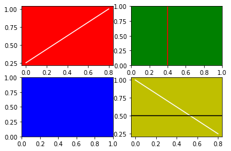

```python
axes=[i for i in range(4)]
for i,c in enumerate('rgby'):
    axes[i]=plt.subplot(221+i,facecolor=c)
plt.plot([0,0.8],[1,0.25],color='white') # 系统维持的当前axes为第四个子画板
axes[0].plot([0,0.8],[0.25,1],color='white')
plt.axhline(0.5,color='black') # 当前axes仍是第四块子画板，画水平线
plt.sca(axes[1]) # 设置第二块子画板为“当前axes”
plt.axvline(0.4,color='red') # 当前axes为第二块子画板，画垂线
```

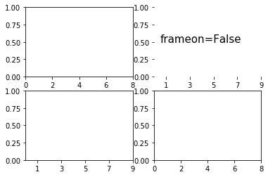

```python
ax1=plt.subplot(2,2,1)
plt.axis([0,8,0,1]) # 就是：ax1.axis(...)
# add a subplot with no frame
ax2=plt.subplot(222,frameon=False)
plt.xticks([1,3,5,7,9])
ax2.annotate('frameon=False',(0.5,0.5),fontsize=15)
# add a subplot that shares the x-axis with ax1
plt.subplot(224,sharex=ax1)
# add a subplot that shares the x-axis with ax2
plt.subplot(223,sharex=ax2)
```

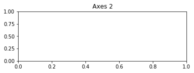

```python
# plot()之后，再使用subplot()首先会删除原先存在的将导致发生重叠的画板
plt.plot([1,2,3]) # 相当于subplot(111)
plt.subplot(212,title='Axes 2') # 或者plt.subplot(211)，结果都是一样的，原来的画板被删除了，前后两个子图矩阵发生重叠，删去前者
# 要想改变此行为，应改而使用add_subplot()或者axes()配置子画板
```

##### tight_layout()用于设置子图的大小和间距

函数原型：`matplotlib.pyplot.tight_layout(pad=1.08, h_pad=None, w_pad=None, rect=None)`  
参数说明：  
pad参数会设置h_pad=w_pad的值，其中h_pad表示上一行子图与其下一行子图的间距，w_pad设置左列子图与其右列子图的间距，默认情况下，h_pad和w_pad与pad是一样的，当然我们可以单独设置。rect是一个四元组：(left, bottom, right, top)，默认为(0,0,1,1)，其构成一个长方形区域，然后子图矩阵将试着去适应它（充满它），通过调整子图的大小。

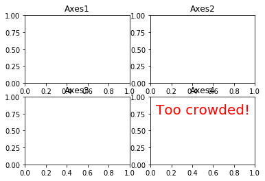

```python
for i in range(4):
    plt.subplot(221+i,title='Axes'+str(i+1))
plt.annotate('Too crowded!',(0.05,0.75),fontsize=20,color='r')
```

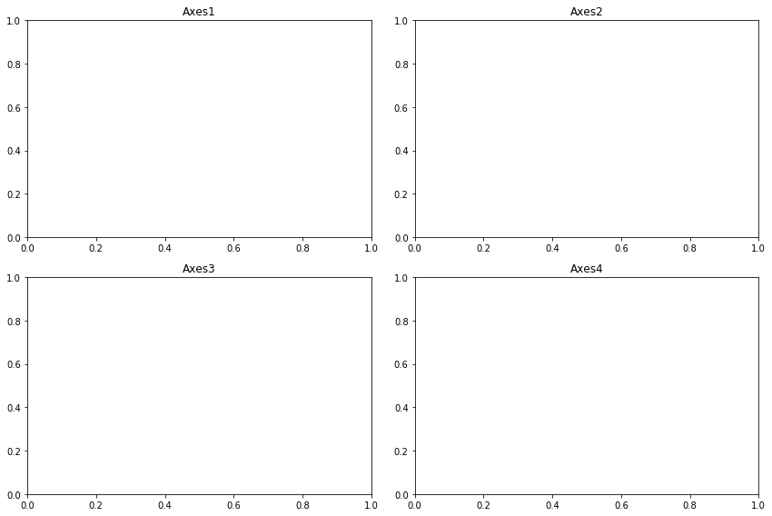

```python
for i in range(4):
    plt.subplot(221+i,title='Axes'+str(i+1))
plt.tight_layout(rect=(0,0,2,2))
```

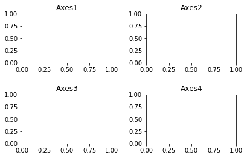

```python
for i in range(4):
    plt.subplot(221+i,title='Axes'+str(i+1))
plt.tight_layout(pad=2) # 默认pad=1，所以一般不加参数就可以得到满意的结果
```

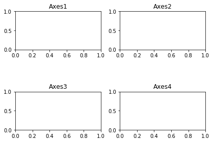

```python
for i in range(4):
    plt.subplot(221+i,title='Axes'+str(i+1))
plt.tight_layout(h_pad=5,w_pad=0) # 试着将w_pad取负
```

##### subplots_adjust()相较于tight_layout更精准地调整当前figure中子图高宽（大小）和间距

函数原型：`matplotlib.pyplot.subplots_adjust(left=None, bottom=None, right=None, top=None, wspace=None, hspace=None)`  
参数说明以及推荐的取值：  
`left = 0.125 # the left side of the subplots of the figure`  
`right = 0.9 # the right side of the subplots of the figure`  
`bottom = 0.1 # the bottom of the subplots of the figure`  
`top = 0.9 # the top of the subplots of the figure`  
`wspace = 0.2 # the amount of width reserved for space between subplots, expressed as a fraction of the average axis width`  
`hspace = 0.2 # the amount of height reserved for space between subplots, expressed as a fraction of the average axis height`  
我曾试着同时使用`tight_layout()`和`subplots_adjust()`来解决一些布局问题，参见"patches与path.ipynb"#Path心形绘制

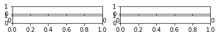

```python
for i in range(4):
    plt.subplot(221+i)
plt.subplots_adjust(bottom=0.9,top=1)
```

#### subplots()创建figure以及创建子图subplot的公共布局

函数原型：`matplotlib.pyplot.subplots(nrows=1, ncols=1, sharex=False, sharey=False, squeeze=True, subplot_kw=None, gridspec_kw=None, **fig_kw)`  
参数说明：  
**nrows, ncols**参数设置子图矩阵的行列数。  
**sharex, sharey**参数：bool or {'none', 'all', 'row', 'col'}, default: False  
这两个参数用于控制同一列或同一行的子图对x轴或y轴的共享行为（见下例）。一般我就取布尔值。当子图具有沿列的共享x轴时，仅创建或配置最底部一行子图的x刻度标签。类似地，当子图具有沿行的共享y轴时，仅创建或配置第一列子图的y刻度标签。若稍后要打开其他子图的轴刻度，应使用tick_params

```
<class 'numpy.ndarray'> (2,)
```

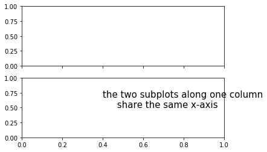

```python
fig,ax=plt.subplots(2,1,sharex=True) # 子图矩阵的每一列共享x轴，“当前axes”为最后一个子图对象
plt.annotate('the two subplots along one column\n     share the same x-axis',(0.4,0.5),fontsize=15)
print(type(ax),ax.shape) # 虽然我们创建的子图矩阵是(2,1)形状，但是返回的是一个一维数组对象（当子图矩阵只有一行或者一列的时候才会如此），其中是创建的全部的axes子图对象
```

```
(2,)
```

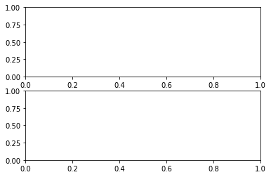

```python
fig,ax=plt.subplots(2,1,sharey=True) # 子图矩阵的每一行共享y轴
print(ax.shape)
```

```
(2, 2)
```

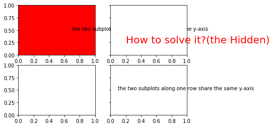

```python
fig,ax=plt.subplots(2,2,sharey=True) # 同上
print(ax.shape)
plt.annotate('the two subplots along one row share the same y-axis',(0.1,0.5)) #“当前axes”为最后一个子图对象
ax[0,0].annotate('the two subplots along one row share the same y-axis',(0.7,0.5))
ax[0,1].annotate('How to solve it?(the Hidden)',(0.2,0.25),fontsize=20,color='r')
ax[0,0].set_facecolor('r')
ax[0,1].set_alpha=0.1 # 为撒不起效呢？
#dir(ax[0,1]) # 命令不行就面向对象，找属性方法
```

[output not shown]

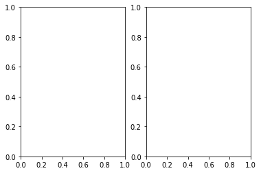

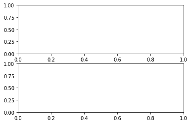

```python
# 绘制多个子图矩阵、调整间距（注意，subplot()只能在一张figure中创建一个子图矩阵，subplots()同样如此，你应该发现了，subplots()返回值一个是figure对象，另一个是子图多维矩阵，即每个子图矩阵仍占有一整个figure，亦即一个figure只能有一个子图矩阵或网格子图（subplot2grid））
plt.subplots(1,2) # 子图矩阵1，同样对subplot()也可如此
plt.subplots(2,1) # 创建了第二个子图矩阵
```

#### subplot2grid()以类似于html中创建表格（譬如课程表表格）的方式创建子图，首先将figure划分成m*n型的网格，其中m、n由形状shape参数指定，然后指定这里面的这几个网格凑成一个子图区域，那几个网格凑成另一个网格对象，如此更加灵活地定制子图，包括大小和位置的设置，欲高度定制还请使用axes()

函数原型：`matplotlib.pyplot.subplot2grid(shape, loc, rowspan=1, colspan=1, fig=None, **kwargs)` 参数说明：  
**shape**参数：二元整数序列[m,n]，将figure划分成m行n列的网格  
**loc**参数：sequence of 2 ints，设置轴域axes（子图）在网格中的位置  
**rowspan**参数设置子图向下跨越的网格行数，默认为1  
**colspan**参数设置子图向右跨越的网格列数，默认为1  
**fig**参数指定子图所在的figure，默认就是“当前figure”  
**kwargs**关键字参数设置其他将传递给add_subplot()的选项

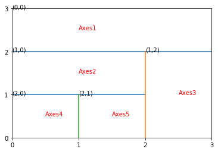

```python
# 欲将figure分解为如下网格（3*3形状），每个格子为一个子图（axes）
plt.axis([0,3,0,3]) # axis()和xticks()、yticks()缺一不可！
plt.xticks([0,1,2,3])
plt.yticks([0,1,2,3])
plt.axhline(2)
plt.plot([0,2],[1,1])
plt.plot([2,2],[0,2])
plt.plot([1,1],[0,1])
# 网格子图无索引编号，此处仅仅作为区分或称呼
plt.annotate('Axes1',(1,2.5),color='r')
plt.annotate('Axes2',(1,1.5),color='r')
plt.annotate('Axes3',(2.5,1),color='r')
plt.annotate('Axes4',(0.5,0.5),color='r')
plt.annotate('Axes5',(1.5,0.5),color='r')
plt.annotate('(0,0)',(0,3))
plt.annotate('(1,0)',(0,2))
plt.annotate('(2,0)',(0,1))
plt.annotate('(2,1)',(1,1))
plt.annotate('(1,2)',(2,2))
```

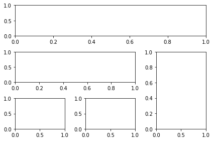

```python
plt.subplot2grid([3,3],loc=[0,0],colspan=3)
plt.subplot2grid([3,3],loc=[1,0],colspan=2)
plt.subplot2grid([3,3],loc=[1,2],rowspan=2)
plt.subplot2grid([3,3],loc=[2,0])
plt.subplot2grid([3,3],loc=[2,1])
plt.tight_layout()
```